# Introduction to R

## filter

To select rows in the dataset based on conditions.

Example: all the flights of january

```r
filter(flights, month==1)
```

```
# A tibble: 36,020 × 19
    year month   day dep_time sched_dep_time dep_delay arr_time sched_arr_time
   <int> <int> <int>    <int>          <int>     <dbl>    <int>          <int>
 1  2023     1     1        1           2038       203      328              3
 2  2023     1     1       18           2300        78      228            135
 3  2023     1     1       31           2344        47      500            426
 4  2023     1     1       33           2140       173      238           2352
 5  2023     1     1       36           2048       228      223           2252
 6  2023     1     1      503            500         3      808            815
 7  2023     1     1      520            510        10      948            949
 8  2023     1     1      524            530        -6      645            710
 9  2023     1     1      537            520        17      926            818
10  2023     1     1      547            545         2      845            852
# ℹ 36,010 more rows
# ℹ 11 more variables: arr_delay <dbl>, carrier <chr>, flight <int>,
#   tailnum <chr>, origin <chr>, dest <chr>, air_time <dbl>, distance <dbl>,
#   hour <dbl>, minute <dbl>, time_hour <dttm>
```

Several conditions

Example: all the flights with departure delay between 10 and 15 minutes

```r
filter(flights, dep_delay >= 10 & dep_delay <= 15)
```

```
# A tibble: 17,829 × 19
    year month   day dep_time sched_dep_time dep_delay arr_time sched_arr_time
   <int> <int> <int>    <int>          <int>     <dbl>    <int>          <int>
 1  2023     1     1      520            510        10      948            949
 2  2023     1     1      613            600        13      834            836
 3  2023     1     1      810            800        10     1153           1147
 4  2023     1     1      811            800        11     1122           1136
 5  2023     1     1      814            800        14     1048           1058
 6  2023     1     1      833            820        13     1436           1435
 7  2023     1     1      840            828        12     1136           1140
 8  2023     1     1      858            845        13     1042           1045
 9  2023     1     1      859            844        15     1207           1209
10  2023     1     1     1005            950        15     1226           1235
# ℹ 17,819 more rows
# ℹ 11 more variables: arr_delay <dbl>, carrier <chr>, flight <int>,
#   tailnum <chr>, origin <chr>, dest <chr>, air_time <dbl>, distance <dbl>,
#   hour <dbl>, minute <dbl>, time_hour <dttm>
```

💡 `filter` can be used with `&` (AND) and `|` (OR) operators.

Possible to supply the result of a function as a condition

Example: flights with the longest distance

```r
filter(flights, distance == max(distance))
```

```
# A tibble: 667 × 19
    year month   day dep_time sched_dep_time dep_delay arr_time sched_arr_time
   <int> <int> <int>    <int>          <int>     <dbl>    <int>          <int>
 1  2023     1     1      949            900        49       NA           1525
 2  2023     1     1     1023           1000        23     1637           1610
 3  2023     1     2      919            900        19     1543           1525
 4  2023     1     2      951           1000        -9     1620           1610
 5  2023     1     3      922            900        22     1535           1525
 6  2023     1     3     1007           1000         7     1630           1610
 7  2023     1     4      912            900        12     1511           1525
 8  2023     1     4     1001           1000         1     1630           1610
 9  2023     1     5      854            900        -6     1454           1525
10  2023     1     5      949           1000       -11     1600           1610
# ℹ 657 more rows
# ℹ 11 more variables: arr_delay <dbl>, carrier <chr>, flight <int>,
#   tailnum <chr>, origin <chr>, dest <chr>, air_time <dbl>, distance <dbl>,
#   hour <dbl>, minute <dbl>, time_hour <dttm>
```

## select

select some columns in the dataset

Example: latitude and longitude

```r
select(airports, lat, lon)
```

```
# A tibble: 1,255 × 2
     lat    lon
   <dbl>  <dbl>
 1  29.7  -85.0
 2  29.7  -95.6
 3  40.7  -75.4
 4  32.4  -99.7
 5  67.1 -158.
 6  35.0 -107.
 7  45.4  -98.4
 8  31.5  -84.2
 9  41.3  -70.1
10  31.6  -97.2
# ℹ 1,245 more rows
```

if we add “-” before the name of the columns it displays all the columns except the one listed

```r
select(airports, -lat)
```

```
# A tibble: 1,255 × 7
   faa   name                                   lon   alt    tz dst   tzone
   <chr> <chr>                                <dbl> <dbl> <dbl> <chr> <chr>
 1 AAF   Apalachicola Regional Airport        -85.0    20    -5 A     America/N…
 2 AAP   Andrau Airpark                       -95.6    79    -6 A     America/C…
 3 ABE   Lehigh Valley International Airport  -75.4   393    -5 A     America/N…
 4 ABI   Abilene Regional Airport             -99.7  1791    -6 A     America/C…
 5 ABL   Ambler Airport                      -158.    334    -9 A     America/A…
 6 ABQ   Albuquerque International Sunport   -107.   5355    -7 A     America/D…
 7 ABR   Aberdeen Regional Airport            -98.4  1302    -6 A     America/C…
 8 ABY   Southwest Georgia Regional Airport   -84.2   197    -5 A     America/N…
 9 ACK   Nantucket Memorial Airport           -70.1    47    -5 A     America/N…
10 ACT   Waco Regional Airport                -97.2   516    -6 A     America/C…
# ℹ 1,245 more rows
```

possible to add arguments to give conditions on the columns returned

```r
select(flights, starts_with("dep_"))
```

```
# A tibble: 435,352 × 2
   dep_time dep_delay
      <int>     <dbl>
 1        1       203
 2       18        78
 3       31        47
 4       33       173
 5       36       228
 6      503         3
 7      520        10
 8      524        -6
 9      537        17
10      547         2
# ℹ 435,342 more rows
```

exists also *ends_with*, *contains* and *matches*

`select` can rename the columns ‘on the fly’

```r
select(airports, latitude=lat, longitude=lon)
```

```
# A tibble: 1,255 × 2
   latitude longitude
      <dbl>     <dbl>
 1     29.7     -85.0
 2     29.7     -95.6
 3     40.7     -75.4
 4     32.4     -99.7
 5     67.1    -158.
 6     35.0    -107.
 7     45.4     -98.4
 8     31.5     -84.2
 9     41.3     -70.1
10     31.6     -97.2
# ℹ 1,245 more rows
```

## rename

to rename the columns, function rename

```r
rename(airports, longitude=lon, latitude=lat, altitude=alt)
```

```
# A tibble: 1,255 × 8
   faa   name                      latitude longitude altitude    tz dst   tzone
   <chr> <chr>                        <dbl>     <dbl>    <dbl> <dbl> <chr> <chr>
 1 AAF   Apalachicola Regional Ai…     29.7     -85.0       20    -5 A     Amer…
 2 AAP   Andrau Airpark                29.7     -95.6       79    -6 A     Amer…
 3 ABE   Lehigh Valley Internatio…     40.7     -75.4      393    -5 A     Amer…
 4 ABI   Abilene Regional Airport      32.4     -99.7     1791    -6 A     Amer…
 5 ABL   Ambler Airport                67.1    -158.       334    -9 A     Amer…
 6 ABQ   Albuquerque Internationa…     35.0    -107.      5355    -7 A     Amer…
 7 ABR   Aberdeen Regional Airport     45.4     -98.4     1302    -6 A     Amer…
 8 ABY   Southwest Georgia Region…     31.5     -84.2      197    -5 A     Amer…
 9 ACK   Nantucket Memorial Airpo…     41.3     -70.1       47    -5 A     Amer…
10 ACT   Waco Regional Airport         31.6     -97.2      516    -6 A     Amer…
# ℹ 1,245 more rows
```

💡 if the new name (or the old one) contains a space quotes are necessary

## arrange

to sort the dataset according to one or several columns

```r
arrange(flights, dep_delay)
```

```
# A tibble: 435,352 × 19
    year month   day dep_time sched_dep_time dep_delay arr_time sched_arr_time
   <int> <int> <int>    <int>          <int>     <dbl>    <int>          <int>
 1  2023     8    16     1839           1929       -50     2254           2218
 2  2023    12     2     2147           2225       -38     2332             35
 3  2023     9     3     1801           1834       -33     1934           2040
 4  2023     8    13     1804           1834       -30     1947           2040
 5  2023     1    28     1930           1959       -29     2308           2336
 6  2023     1    18     2103           2129       -26     2301           2336
 7  2023     5     5     1129           1155       -26     1337           1420
 8  2023     4    16      925            950       -25     1102           1140
 9  2023    11    14     2055           2120       -25     2215           2239
10  2023    12     6     2234           2259       -25     2350             30
# ℹ 435,342 more rows
# ℹ 11 more variables: arr_delay <dbl>, carrier <chr>, flight <int>,
#   tailnum <chr>, origin <chr>, dest <chr>, air_time <dbl>, distance <dbl>,
#   hour <dbl>, minute <dbl>, time_hour <dttm>
```

function `desc()` to reverse the order

```r
arrange(flights, desc(dep_delay))
```

```
# A tibble: 435,352 × 19
    year month   day dep_time sched_dep_time dep_delay arr_time sched_arr_time
   <int> <int> <int>    <int>          <int>     <dbl>    <int>          <int>
 1  2023    12    17     1953           1340      1813     2155           1543
 2  2023    10     1     1240            659      1781     1407            835
 3  2023     4    25     1201            659      1742     1315            818
 4  2023     2     7     2045           1700      1665     2352           2025
 5  2023     4    20      926            619      1627     1135            822
 6  2023    10    29      856            600      1616     1050            805
 7  2023     4    30     1818           1617      1561     2001           1820
 8  2023     3    17     2027           1830      1557     2346           2139
 9  2023     3    29      633            525      1508      820            700
10  2023     3    19     1154           1201      1433     1321           1335
# ℹ 435,342 more rows
# ℹ 11 more variables: arr_delay <dbl>, carrier <chr>, flight <int>,
#   tailnum <chr>, origin <chr>, dest <chr>, air_time <dbl>, distance <dbl>,
#   hour <dbl>, minute <dbl>, time_hour <dttm>
```

several columns

```r
arrange(flights, month, dep_delay)
```

```
# A tibble: 435,352 × 19
    year month   day dep_time sched_dep_time dep_delay arr_time sched_arr_time
   <int> <int> <int>    <int>          <int>     <dbl>    <int>          <int>
 1  2023     1    28     1930           1959       -29     2308           2336
 2  2023     1    18     2103           2129       -26     2301           2336
 3  2023     1    30     2105           2129       -24     2340           2350
 4  2023     1    25     1844           1905       -21     2200           2222
 5  2023     1    27      539            600       -21      700            720
 6  2023     1    19      820            840       -20      928           1007
 7  2023     1    19     1932           1952       -20     2307           2301
 8  2023     1    25      715            735       -20      916            950
 9  2023     1    28     1435           1455       -20     1734           1805
10  2023     1     9      816            835       -19     1008           1040
# ℹ 435,342 more rows
# ℹ 11 more variables: arr_delay <dbl>, carrier <chr>, flight <int>,
#   tailnum <chr>, origin <chr>, dest <chr>, air_time <dbl>, distance <dbl>,
#   hour <dbl>, minute <dbl>, time_hour <dttm>
```

## mutate

to create new columns/variables

Creation of a column named air_time_hours

```r
flights <- mutate(flights, air_time_hours = air_time / 60)
```

possible to create several columns at once

```r
flights <- mutate(
    flights,
    distance_km = distance / 0.62137,
    speed = distance_km / air_time_hours
)
select(flights, "Air time"=air_time_hours, "Distance (km)"=distance_km, "Speed"=speed)
```

```
# A tibble: 435,352 × 3
   `Air time` `Distance (km)` Speed
        <dbl>           <dbl> <dbl>
 1       6.12           4023.  658.
 2       1.8            1223.  680.
 3       3.17           2536.  801.
 4       1.8            1024.  569.
 5       1.33            785.  589.
 6       2.57           1746.  680.
 7       3.2            2536.  793.
 8       1.98           1157.  583.
 9       4.3            2253.  524.
10       2.62           1714.  655.
# ℹ 435,342 more rows
```

## The pipe

Actions can be chained with the `pipe`. The pipe operator is `|>`.

```r
flights |>
  filter(dep_delay >= 10 & dep_delay <= 15) |>
  arrange(desc(dep_delay)) |>
  select(flight, origin, dest, dep_delay, air_time_hours, distance_km, speed) |>
  head(5)
```

```
# A tibble: 5 × 7
  flight origin dest  dep_delay air_time_hours distance_km speed
   <int> <chr>  <chr>     <dbl>          <dbl>       <dbl> <dbl>
1    786 EWR    RSW          15           2.73       1719.  629.
2    910 LGA    MSY          15           2.92       1904.  653.
3    908 EWR    MSY          15           2.88       1878.  651.
4    503 EWR    SFO          15           5.68       4128.  726.
5     27 JFK    SLC          15           4.97       3203.  645.
```

⚠️ the actions are chained (pipeline), but nothing is stored. To keep a track of these actions you have to start with an assignment to an object.

```r
delays <- flights |>
  filter(dep_delay >= 10 & dep_delay <= 15) |>
  arrange(desc(dep_delay)) |>
  select(flight, origin, dest, dep_delay, air_time_hours, distance_km, speed)
```

The result of the pipeline will be stored in the `delays` object

## 💻 Practice

1. display rows 100 to 105 (dataset flights)
2. display the flights of july
3. display the flights that had a delay (arr_delay) between 5 and 15 minutes. The result must be displayed in descending order.
4. select the columns name, lat and lon of the airports dataset and display lat and lon with the names latitude and longitude
5. in the airports dataset, create a new variable alt_metres which contains the altitude in the metric system (convert feet to meters by dividing the variable by 3.28).

## group_by

- allows to apply a function to grouped data
- example: we group the data by month and display the first index of each group (combination of `group_by` and `slice`)

```r
flights |>
  group_by(month) |>
  slice(1)
```

```
# A tibble: 12 × 22
# Groups:   month [12]
    year month   day dep_time sched_dep_time dep_delay arr_time sched_arr_time
   <int> <int> <int>    <int>          <int>     <dbl>    <int>          <int>
 1  2023     1     1        1           2038       203      328              3
 2  2023     2     1      453            501        -8      934            943
 3  2023     3     1        6           2259        67      104              5
 4  2023     4     1        1           2205       116      111           2317
 5  2023     5     1       10           2225       105      357            227
 6  2023     6     1       39           1659       460      325           2000
 7  2023     7     1        2           2256        66      401            300
 8  2023     8     1        3           2035       208      224           2330
 9  2023     9     1       12           2236        96      120           2359
10  2023    10     1       58           2250       128      302            118
11  2023    11     1        2           2340        22       57             54
12  2023    12     1      506            509        -3      807            823
# ℹ 14 more variables: arr_delay <dbl>, carrier <chr>, flight <int>,
#   tailnum <chr>, origin <chr>, dest <chr>, air_time <dbl>, distance <dbl>,
#   hour <dbl>, minute <dbl>, time_hour <dttm>, air_time_hours <dbl>,
#   distance_km <dbl>, speed <dbl>
```

Group the data by company, calculate the average delay and place the result in a new variable called mean_delay (combination of `group_by` and `mutate`)  
`mean_delay` is the average delay of each company

```r
flights |>
  group_by(carrier) |>
  mutate(mean_delay = mean(dep_delay, na.rm=T)) |>
  slice(1) |>
  select(carrier, mean_delay)
```

```
# A tibble: 14 × 2
# Groups:   carrier [14]
   carrier mean_delay
   <chr>        <dbl>
 1 9E            7.44
 2 AA           14.2
 3 AS           12.0
 4 B6           23.8
 5 DL           15.1
 6 F9           35.7
 7 G4            3.98
 8 HA           22.9
 9 MQ           10.5
10 NK           18.2
11 OO           19.8
12 UA           17.6
13 WN           16.1
14 YX            4.21
```

Group the data by month and display the flights with the longest delay (combination of `group_by` and `filter`)  
*displays the flights with the longest delay for each month*

```r
flights |>
  group_by(month) |>
  filter(dep_delay == max(dep_delay, na.rm=T)) |>
  select(month, dep_delay, carrier, origin, dest) |>
  arrange(month)
```

```
# A tibble: 12 × 5
# Groups:   month [12]
   month dep_delay carrier origin dest
   <int>     <dbl> <chr>   <chr>  <chr>
 1     1      1201 AA      JFK    STT
 2     2      1665 AA      LGA    DFW
 3     3      1557 AA      EWR    DFW
 4     4      1742 AA      LGA    DCA
 5     5      1312 UA      LGA    ORD
 6     6      1353 AA      LGA    DFW
 7     7      1413 AA      LGA    DFW
 8     8      1161 F9      LGA    ATL
 9     9      1369 AA      JFK    LAX
10    10      1781 AA      EWR    ORD
11    11      1074 DL      JFK    ATL
12    12      1813 AA      EWR    CLT
```

possible to group by several variables

```r
flights |>
  group_by(month, carrier) |>
  filter(dep_delay == max(dep_delay, na.rm=T)) |>
  select(month, carrier, dep_delay) |>
  arrange(month, carrier)
```

```
# A tibble: 165 × 3
# Groups:   month, carrier [165]
   month carrier dep_delay
   <int> <chr>       <dbl>
 1     1 9E            773
 2     1 AA           1201
 3     1 AS            266
 4     1 B6            739
 5     1 DL           1074
 6     1 F9           1006
 7     1 G4             84
 8     1 HA            167
 9     1 MQ            140
10     1 NK            761
# ℹ 155 more rows
```

## summarise

It allows to calculate a summary statistic on a variable.

```r
flights |>
  summarise(
    mean_dep_delay=mean(dep_delay, na.rm=T),
    mean_arr_delay=mean(arr_delay, na.rm=T)
  )
```

```
# A tibble: 1 × 2
  mean_dep_delay mean_arr_delay
           <dbl>          <dbl>
1           13.8           4.34
```

Combined with `group_by`, `summarise` is extremely powerful.

*Display the average delay of each company and arrange the result from the longest delay to the shortest*

```r
flights |>
  group_by(carrier) |>
  summarise(mean_dep_delay=mean(dep_delay, na.rm=T)) |>
  arrange(desc(mean_dep_delay))
```

```
# A tibble: 14 × 2
   carrier mean_dep_delay
   <chr>            <dbl>
 1 F9               35.7
 2 B6               23.8
 3 HA               22.9
 4 OO               19.8
 5 NK               18.2
 6 UA               17.6
 7 WN               16.1
 8 DL               15.1
 9 AA               14.2
10 AS               12.0
11 MQ               10.5
12 9E                7.44
13 YX                4.21
14 G4                3.98
```

**`n=n()`**

To get the information about the number of observations used to make the calculations

```r
flights |>
  group_by(carrier) |>
  summarise(
    mean_dep_delay=mean(dep_delay, na.rm=T),
    n=n()
  ) |>
  arrange(desc(mean_dep_delay))
```

```
# A tibble: 14 × 3
   carrier mean_dep_delay     n
   <chr>            <dbl> <int>
 1 F9               35.7   1286
 2 B6               23.8  66169
 3 HA               22.9    366
 4 OO               19.8   6432
 5 NK               18.2  15189
 6 UA               17.6  79641
 7 WN               16.1  12385
 8 DL               15.1  61562
 9 AA               14.2  40525
10 AS               12.0   7843
11 MQ               10.5    357
12 9E                7.44 54141
13 YX                4.21 88785
14 G4                3.98   671
```

With two variables in `group_by`

```r
flights |>
  group_by(month, dest) |>
  summarise(n=n()) |>
  arrange(desc(n))
```

```
# A tibble: 1,274 × 3
# Groups:   month [12]
   month dest      n
   <int> <chr> <int>
 1     3 BOS    2008
 2     5 BOS    1798
 3     4 BOS    1768
 4     2 BOS    1745
 5     1 BOS    1693
 6     3 ORD    1654
 7     3 MCO    1624
 8     1 ORD    1603
 9     5 ORD    1603
10    12 MCO    1585
# ℹ 1,264 more rows
```

💡 If only the effectives are needed, the `count` function can be used

```r
flights |>
  count(month, dest) |>
  arrange(desc(n))
```

```
# A tibble: 1,274 × 3
   month dest      n
   <int> <chr> <int>
 1     3 BOS    2008
 2     5 BOS    1798
 3     4 BOS    1768
 4     2 BOS    1745
 5     1 BOS    1693
 6     3 ORD    1654
 7     3 MCO    1624
 8     1 ORD    1603
 9     5 ORD    1603
10    12 MCO    1585
# ℹ 1,264 more rows
```

Variable calculated by the `summarise` function can be used to create an new variable with `mutate`

```r
flights |>
  group_by(month, dest) |>
  summarise(n=n()) |>
  mutate(pourcentage=n/sum(n) * 100) |>
  arrange(desc(pourcentage)) |>
  head()
```

```
# A tibble: 6 × 4
# Groups:   month [6]
  month dest      n pourcentage
  <int> <chr> <int>       <dbl>
1     3 BOS    2008        5.08
2     2 BOS    1745        5.02
3    12 MCO    1585        4.75
4     4 BOS    1768        4.72
5     1 BOS    1693        4.70
6     5 BOS    1798        4.64
```

## across

`across()` allows to apply a function to a selection of columns inside `summarise()` or `mutate()`.

Basic Syntax `across(.cols = selection, .fns = function)`

```r
# Example: Calculate the mean for all numeric variables
hdv2003 |>
  group_by(sexe) |>
  summarise(across(where(is.numeric), \(x) mean(x, na.rm = TRUE)))
```

```
# A tibble: 2 × 6
  sexe     id   age poids freres.soeurs heures.tv
  <fct> <dbl> <dbl> <dbl>         <dbl>     <dbl>
1 Homme 1002.  48.2 5728.          3.28      2.22
2 Femme  999.  48.2 5379.          3.29      2.27
```

ℹ️ The `\(x)` syntax is a “shortcut” for creating an anonymous function in R (since version 4.1). It tells R: “take each column x and apply this transformation to it.”

Example: Massive Recoding

```r
# Convert all character columns to factors in one go
hdv2003 <- hdv2003 |>
  mutate(across(where(is.character), as.factor))
```

## 💻 Practice

1. display the number of flights by month and display the result in ascending order
2. calculate the number of flights to Los Angeles (code LAX) for each month
3. calculate the number of flights by month and by destination and display only the max
4. calculate the number of flights by month and create a variable that displays the percentage it represents of the annual flights

# Descriptive statistics

ℹ️ Descriptive statistics are numerical summaries that describe and summarize the features of a dataset.

- the first step consists in examining each variable separately (univariate analysis)
- the second step consists in exploring the relationships between pairs of variables (bivariate analysis)
- the third step consists in examining the relationships between multiple variables simultaneously (multivariate analysis). This can involve techniques such as regression analysis, factor analysis, principal component analysis, cluster analysis etc.

*Use of `hdv2003`*

## Univariate analysis

The analysis depends on the type of the variable:

- quantitative (age, income, etc.) -> numeric vector
- qualitative (gender, profession, etc.) -> factorial vector

### Quantitative variable

- simple statistics: minimum, maximum, mean, median, variance, standard-deviation
- corresponding functions are min(), max(), range(), mean(), median(), var(), sd()
- one can also compute the quartiles with the quantile function

The `summary()` function displays all this information directly

```r
summary(hdv2003$age)
```

```
   Min. 1st Qu.  Median    Mean 3rd Qu.    Max.
  18.00   35.00   48.00   48.16   60.00   97.00
```

### Qualitative variable

the `table()` function counts the number of observations of each category/factor - it is called a contingency table

- add the argument `useNa="ifany"` to count for the NA values
- The summary() function applied on a categorical variable calls this table function

```r
table(hdv2003$qualif, useNA="ifany")
```

```
      Ouvrier specialise         Ouvrier qualifie               Technicien
                     203                      292                       86
Profession intermediaire                    Cadre                  Employe
                     160                      260                      594
                   Autre                     <NA>
                      58                      347
```

If percentages are preferred over effectives, use the function `prop.table` with the result of the `table` function as argument

```r
prop.table(table(hdv2003$qualif, useNA="ifany")) * 100
```

```
      Ouvrier specialise         Ouvrier qualifie               Technicien
                   10.15                    14.60                     4.30
Profession intermediaire                    Cadre                  Employe
                    8.00                    13.00                    29.70
                   Autre                     <NA>
                    2.90                    17.35
```

the `questionr` package provides the `freq()` function  
useful arguments: valid=F to hide the “valid” columns (columns with NA values); total=T to add a row with the total, and sort=“dec” (or “inc”) to display values in the decreasing (increasing) order

```r
freq(hdv2003$qualif, valid=F, total=T, sort="dec")
```

```
                            n     %
Employe                   594  29.7
Ouvrier qualifie          292  14.6
Cadre                     260  13.0
Ouvrier specialise        203  10.2
Profession intermediaire  160   8.0
Technicien                 86   4.3
Autre                      58   2.9
NA                        347  17.3
Total                    2000 100.0
```

## 💻 Practice

1. analyse the variable `heures.tv`
2. analyse the variable `trav.imp`

## gtsummary

`gtsummary` creates publication-ready analytical and summary tables.  
It automatically handles labels, levels, and missing values.

```r
library(gtsummary)

# Create a basic summary table
hdv2003 |>
  select(sexe, age, sport) |>
  tbl_summary()
```

| **Characteristic** | **N = 2,000**<sup>1</sup> |
| --- | --- |
| sexe |  |
| Homme | 899 (45%) |
| Femme | 1,101 (55%) |
| age | 48 (35, 60) |
| sport |  |
| Non | 1,277 (64%) |
| Oui | 723 (36%) |

<sup>1</sup> n (%); Median (Q1, Q3)

You can easily compare groups and add statistical tests in one line.

It automatically chooses the right test (t-test, Wilcoxon, Chi-squared) based on data distribution.

```r
hdv2003 |>
  select(sexe, age, sport, heures.tv) |>
  tbl_summary(by = sexe) |> # Split by gender
  add_p() |>                # Add p-values
  add_overall()             # Add a column for the whole sample
```

| **Characteristic** | **Overall** N = 2,000<sup>1</sup> | **Homme** N = 899<sup>1</sup> | **Femme** N = 1,101<sup>1</sup> | **p-value**<sup>2</sup> |
| --- | --- | --- | --- | --- |
| age | 48 (35, 60) | 48 (35, 60) | 47 (35, 60) | 0.8 |
| sport |  |  |  | <0.001 |
| Non | 1,277 (64%) | 530 (59%) | 747 (68%) |  |
| Oui | 723 (36%) | 369 (41%) | 354 (32%) |  |
| heures.tv | 2.00 (1.00, 3.00) | 2.00 (1.00, 3.00) | 2.00 (1.00, 3.00) | 0.9 |
| Unknown | 5 | 4 | 1 |  |

<sup>1</sup> Median (Q1, Q3); n (%)  
<sup>2</sup> Wilcoxon rank sum test; Pearson’s Chi-squared test

**Customizing for Publication**

Labels: Use label = list(var ~ “Custom Label”) to make it readable.

Statistics: Choose to display mean, SD, median, or percentages.

Export: Works perfectly with Quarto to export to Word, PDF, or HTML.

```r
table1 <- hdv2003 |>
  select(sexe, age, sport) |>
  tbl_summary(
    by = sport,
    label = list(age ~ "Age (years)", sexe ~ "Gender")
  )
table1
```

| **Characteristic** | **Non** N = 1,277<sup>1</sup> | **Oui** N = 723<sup>1</sup> |
| --- | --- | --- |
| Gender |  |  |
| Homme | 530 (42%) | 369 (51%) |
| Femme | 747 (58%) | 354 (49%) |
| Age (years) | 52 (40, 64) | 39 (29, 52) |

<sup>1</sup> n (%); Median (Q1, Q3)

ℹ️ Use theme_gtsummary_journal(“journal_name”) to automatically apply the formatting style of major scientific journals.

## Bivariate analysis

- to analyse the relationship between two variables
- the analyse depends on the types of the variables
  - both qualitative
  - one qualitative and one quantitative
  - both quantitative

### Two qualitatives variables

a contingency table with the `table` function, with two vectors

```r
(tb_prof_genre <- table(hdv2003$qualif, hdv2003$sexe))
```

```
                           Homme Femme
  Ouvrier specialise          96   107
  Ouvrier qualifie           229    63
  Technicien                  66    20
  Profession intermediaire    88    72
  Cadre                      145   115
  Employe                     96   498
  Autre                       21    37
```

- the `prop.table` function computes the percentages
- use the `margin` argument to indicate the axis (row=1, column=2) by which the percentages must be computed

```r
prop.table(tb_prof_genre, margin=1) * 100
```

```
                              Homme    Femme
  Ouvrier specialise       47.29064 52.70936
  Ouvrier qualifie         78.42466 21.57534
  Technicien               76.74419 23.25581
  Profession intermediaire 55.00000 45.00000
  Cadre                    55.76923 44.23077
  Employe                  16.16162 83.83838
  Autre                    36.20690 63.79310
```

`round()` to set the number of decimals

```r
round(prop.table(tb_prof_genre, margin=1) * 100, 2)
```

```
                           Homme Femme
  Ouvrier specialise       47.29 52.71
  Ouvrier qualifie         78.42 21.58
  Technicien               76.74 23.26
  Profession intermediaire 55.00 45.00
  Cadre                    55.77 44.23
  Employe                  16.16 83.84
  Autre                    36.21 63.79
```

If we change the axis, the interpretation is different. Below the distribution of professions for each gender.

```r
round(prop.table(table(hdv2003$qualif, hdv2003$sexe), margin=2) * 100, 2)
```

```
                           Homme Femme
  Ouvrier specialise       12.96 11.73
  Ouvrier qualifie         30.90  6.91
  Technicien                8.91  2.19
  Profession intermediaire 11.88  7.89
  Cadre                    19.57 12.61
  Employe                  12.96 54.61
  Autre                     2.83  4.06
```

`questionr` provides 2 functions, `lprop` and `cprop` (with one decimal by default)

```r
lprop(tb_prof_genre)
```

```
                           Homme Femme Total
  Ouvrier specialise        47.3  52.7 100.0
  Ouvrier qualifie          78.4  21.6 100.0
  Technicien                76.7  23.3 100.0
  Profession intermediaire  55.0  45.0 100.0
  Cadre                     55.8  44.2 100.0
  Employe                   16.2  83.8 100.0
  Autre                     36.2  63.8 100.0
  Ensemble                  44.8  55.2 100.0
```

some useful arguments: add “%”, add effectives and change the number of decimals

```r
lprop(tb_prof_genre, percent=T, n=T, digits=2)
```

```
                           Homme    Femme    Total    n
  Ouvrier specialise         47.29%   52.71%  100.00%  203
  Ouvrier qualifie           78.42%   21.58%  100.00%  292
  Technicien                 76.74%   23.26%  100.00%   86
  Profession intermediaire   55.00%   45.00%  100.00%  160
  Cadre                      55.77%   44.23%  100.00%  260
  Employe                    16.16%   83.84%  100.00%  594
  Autre                      36.21%   63.79%  100.00%   58
  Ensemble                   44.83%   55.17%  100.00% 1653
```

**Statistical test**

- we can test for the independence of the two variables with a $\chi^2$
- $H_0$: the two variables (profession and gender) are independent

```r
chisq.test(tb_prof_genre)
```

```
    Pearson's Chi-squared test

data:  tb_prof_genre
X-squared = 387.56, df = 6, p-value < 2.2e-16
```

- **X-squared** is the test value, it is a measure of the distance between the data and a theoretical distribution under the hypothesis that the two variables are independents
- **df** is the degree of freedom
- **p-value** is the probability that $H_0$ is observed. The p-value is lower than 5%, the standard threshold, so we reject $H_0$ and conclude that the two variables are not independent from each other.

### One qualitative and one quantitative variable

Is the distribution of the numerical (quantitative) variable significantly different across the various levels of the categorical (qualitative) variable?

The mean of the quantitative variable for each category of the qualitative variable

```r
hdv2003 |>
  group_by(sport) |>
  summarise(mean(age))
```

```
# A tibble: 2 × 2
  sport `mean(age)`
  <fct>       <dbl>
1 Non          52.3
2 Oui          40.9
```

**Statistical test**

Test whether the average age is different depending on whether the individual practices sport or not.

If the quantitative variable follows a normal distribution use the *ttest* (student) parametric test, otherwise the *Mann-Whitney* test.  
*if the qualitative variable has more than 2 levels, use the ANOVA test (parametric, `aov()`) or Kruskal-Wallis test (non parametric, `kruskal.test()`)*

To test the normality of the distribution, we can use the *shapiro* test. $H_0$ the vector follows a normal distribution

```r
shapiro.test(hdv2003$age)
```

```
    Shapiro-Wilk normality test

data:  hdv2003$age
W = 0.98081, p-value = 9.351e-16
```

the p-value is lower than 5% so we reject $H_0$, the non-parametric MW test must be used

**Mann-Whitney test** : wilcox.test with the argument paired=F (default) because the sample are drawn from different populations (athletes and non-athletes are not the same individuals)

```r
wilcox.test(age ~ sport, data=hdv2003)
```

```
    Wilcoxon rank sum test with continuity correction

data:  age by sport
W = 640577, p-value < 2.2e-16
alternative hypothesis: true location shift is not equal to 0
```

**Student test** ($H_0$: the average age is not significantly different between athletes and non-athletes)

```r
t.test(age ~ sport, data=hdv2003)
```

```
    Welch Two Sample t-test

data:  age by sport
t = 15.503, df = 1600.4, p-value < 2.2e-16
alternative hypothesis: true difference in means between group Non and group Oui is not equal to 0
95 percent confidence interval:
  9.893117 12.759002
sample estimates:
mean in group Non mean in group Oui
         52.25137          40.92531
```

In both cases the p-value is lower than 5% which means that the age of athletes is significantly different (here lower) than the age of non-athletes.

### Two quantitative variables

Load a new dataset, provided by *`questionr`*

```r
data("rp2018")
```

These are data on French municipalities with more than 2000 inhabitants `?rp2018` for a description

```r
names(rp2018)
```

```
 [1] "code_insee"       "commune"          "code_region"      "region"
 [5] "code_departement" "departement"      "pop_tot"          "pop_cl"
 [9] "pop_0_14"         "pop_15_29"        "pop_18_24"        "pop_75p"
[13] "pop_femmes"       "pop_act_15p"      "pop_chom"         "pop_agric"
[17] "pop_indep"        "pop_cadres"       "pop_interm"       "pop_empl"
[21] "pop_ouvr"         "pop_scol_18_24"   "pop_non_scol_15p" "pop_dipl_aucun"
[25] "pop_dipl_bepc"    "pop_dipl_capbep"  "pop_dipl_bac"     "pop_dipl_sup2"
[29] "pop_dipl_sup34"   "pop_dipl_sup"     "log_rp"           "log_proprio"
[33] "log_loc"          "log_hlm"          "log_sec"          "log_maison"
[37] "log_appart"       "age_0_14"         "age_15_29"        "age_75p"
[41] "femmes"           "chom"             "agric"            "indep"
[45] "cadres"           "interm"           "empl"             "ouvr"
[49] "etud"             "dipl_aucun"       "dipl_bepc"        "dipl_capbep"
[53] "dipl_bac"         "dipl_sup2"        "dipl_sup34"       "dipl_sup"
[57] "resid_sec"        "proprio"          "locataire"        "hlm"
[61] "maison"           "appart"
```

**Correlation coefficient**

The coefficient varies between -1 and +1, it measures the strength and the direction of the relation between two quantitative variables. A coefficient close to -1 indicates a strong negative relation (when one variable increases the other decreases), and a coefficient close to 1 a positive relation (both variables go in the same direction).

```r
cor(rp2018$cadres, rp2018$dipl_sup)
```

```
[1] 0.9291504
```

The statistical test can be called with the `cor.test()` function

$H_0$ : the coefficient is equal to 0

```r
cor.test(rp2018$cadres, rp2018$dipl_sup)
```

```
    Pearson's product-moment correlation

data:  rp2018$cadres and rp2018$dipl_sup
t = 184.94, df = 5415, p-value < 2.2e-16
alternative hypothesis: true correlation is not equal to 0
95 percent confidence interval:
 0.9254182 0.9327024
sample estimates:
      cor
0.9291504
```

we reject $H_0$, the correlation between the two variables is significantly different from zero

💡 If the relation is not linear the **Spearman correlation test** (based on ranks) is more suitable : `cor.test(rp2018$cadres, rp2018$dipl_sup, method="spearman")`

### 💻 Pratice

With the dataset *rp2018*

1. Analyse the relation between region and pop_chom :
- calculate the average number of unemployed people by departement
- test if the average number of unemployed people is different between the regions
2. Analyse the relationship between pop_tot and pop_chom

## Effect sizes

- With a large enough $N$, even a trivial difference becomes statistically significant ($p < 0.05$).
- Effect sizes measure the practical significance or the strength of the relationship, independent of sample size.

*Comparing Two Means (Cohen’s $d$)* : When comparing a quantitative variable across two groups (e.g., Age by Sport):

- $d = 0.2$: Small effect.
- $d = 0.5$: Medium effect.
- $d = 0.8$: Large effect.

```r
# Standardized difference between groups
cohens_d(age ~ sport, data = hdv2003)
```

```
Cohen's d |       95% CI
------------------------
0.71      | [0.61, 0.80]

- Estimated using pooled SD.
```

*Categorical Variables (Cramér’s $V$)* : For $\chi^2$ tests (two qualitative variables), the p-value tells you if they are dependent, but Cramér’s $V$ tells you how strongly.  
Range: 0 (no association) to 1 (perfect association).

```r
# Association between qualification and gender
table_prof <- table(hdv2003$qualif, hdv2003$sexe)
cramers_v(table_prof)
```

```
Cramer's V (adj.) |       95% CI
--------------------------------
0.48              | [0.44, 1.00]

- One-sided CIs: upper bound fixed at [1.00].
```

## Statistical Power Analysis

→ To determine the minimum sample size ($N$) needed to detect an effect of a given size with a certain level of confidence.

Key parameters:

- Effect Size: The magnitude of the phenomenon in the population.
- Alpha ($\alpha$): Usually 0.05 (significance level).
- Power ($1-\beta$): Usually 0.80 or higher in social sciences.

Implementation with `pwr`

The pwr package provides functions for different types of tests (t-test, ANOVA, Chi-square, etc.).

```r
library(pwr)

# Example: How many participants for a t-test?
# To detect a medium effect (d = 0.5) with 80% power
pwr.t.test(d = 0.5, power = 0.80, sig.level = 0.05, type = "two.sample")
```

```
     Two-sample t test power calculation

              n = 63.76561
              d = 0.5
      sig.level = 0.05
          power = 0.8
    alternative = two.sided

NOTE: n is number in *each* group
```

## Sensitivity Power Analysis

You already have your data (e.g., $N = 200$) and you want to know what effect size you can realistically “capture”.

→ “What is the smallest effect I can detect with 80% power?”

```r
# Find the effect size (d) for a t-test with N = 100 per group
pwr.t.test(n = 100, sig.level = 0.05, power = 0.80, type = "two.sample")
```

```
     Two-sample t test power calculation

              n = 100
              d = 0.3981407
      sig.level = 0.05
          power = 0.8
    alternative = two.sided

NOTE: n is number in *each* group
```

💡 If the detectable effect size ($d$) is 0.40 but the literature suggests the real effect is 0.15, your study is underpowered. You should warn your reader that a non-significant result might be a False Negative (Type II Error).

**Which Power Test to Use?**

Depending on your research design, choose the appropriate `pwr` function:

- **Comparing 2 Means**: `pwr.t.test(type = ...)`
  - `two.sample`: Independent groups.
  - `paired`: Same individuals (Pre/Post).
- **Comparing >2 Means**: `pwr.anova.test(k = 3, ...)`
- **Testing a Correlation**: `pwr.r.test(r = 0.3, ...)`
- **Chi-Square (Associations)**: `pwr.chisq.test(w = 0.3, df = 1, ...)`

# Data Visualization

With `ggplot2` package

*We use a subset of the dataset `rp2018`*

```r
rp <- rp2018 |> filter(departement %in% c("Oise", "Rhône", "Hauts-de-Seine", "Lozère", "Bouches-du-Rhône"))
head(rp)
```

```
# A tibble: 6 × 62
  code_insee commune     code_region region code_departement departement pop_tot
  <chr>      <chr>       <chr>       <chr>  <chr>            <chr>         <dbl>
1 13001      Aix-en-Pro… 93          Prove… 13               Bouches-du…  143097
2 13002      Allauch     93          Prove… 13               Bouches-du…   20860
3 13003      Alleins     93          Prove… 13               Bouches-du…    2516
4 13004      Arles       93          Prove… 13               Bouches-du…   51031
5 13005      Aubagne     93          Prove… 13               Bouches-du…   47208
6 13007      Auriol      93          Prove… 13               Bouches-du…   12771
# ℹ 55 more variables: pop_cl <fct>, pop_0_14 <dbl>, pop_15_29 <dbl>,
#   pop_18_24 <dbl>, pop_75p <dbl>, pop_femmes <dbl>, pop_act_15p <dbl>,
#   pop_chom <dbl>, pop_agric <dbl>, pop_indep <dbl>, pop_cadres <dbl>,
#   pop_interm <dbl>, pop_empl <dbl>, pop_ouvr <dbl>, pop_scol_18_24 <dbl>,
#   pop_non_scol_15p <dbl>, pop_dipl_aucun <dbl>, pop_dipl_bepc <dbl>,
#   pop_dipl_capbep <dbl>, pop_dipl_bac <dbl>, pop_dipl_sup2 <dbl>,
#   pop_dipl_sup34 <dbl>, pop_dipl_sup <dbl>, log_rp <dbl>, …
```

**Basic principles of ggplot2**

- Initialize the graphic function with `ggplot()`
- Add graphical elements using `geom_` (histogram, scatter plot, boxplot, bars, curves, …)
- Customize the graphics using arguments in `geom_` functions and `aes()`
- The `aes()` function maps dataset variables to graphical elements

## One variable

### Histogram

**`geom_histogram`** to display the distribution of a quantitative variable

```r
ggplot(data=rp) +
  geom_histogram(aes(x=cadres))
```

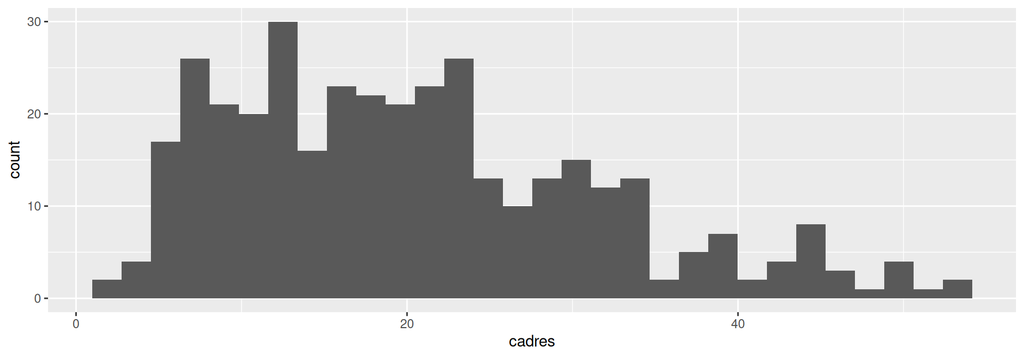

3 options to control the binning of data:

- bins = X: Specify the number of bins directly. X represents the desired number of bins. This method allows ggplot2 to automatically calculate the bin width based on the range of the data and the specified number of bins.
- binwidth = X: Set the width of each bin. X represents the desired width of each bin. This gives you direct control over the size of the bins but indirectly determines the number of bins based on the data range.
- breaks = vector: Define the bin edges explicitly. In this case, you provide a numeric vector that specifies the boundaries of the bins. This method offers the highest level of control, allowing you to specify irregular bin widths if needed.

```r
ggplot(data=rp) +
  geom_histogram(aes(x=cadres), breaks=seq(0, 60, 10))
```

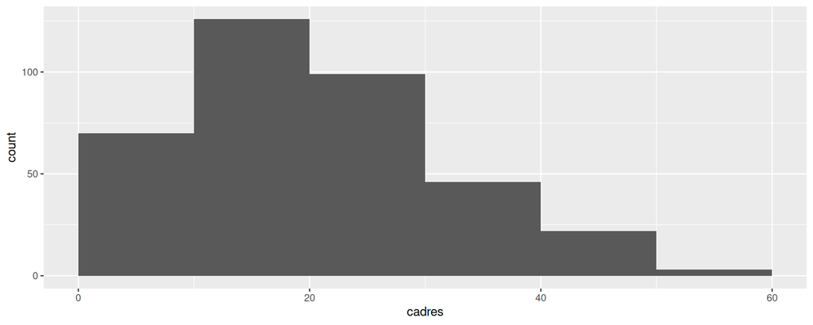

### Density plot

**`geom_density`**: to display the density of a quantitative variable

```r
ggplot(data=rp) +
  geom_density(aes(x=cadres))
```

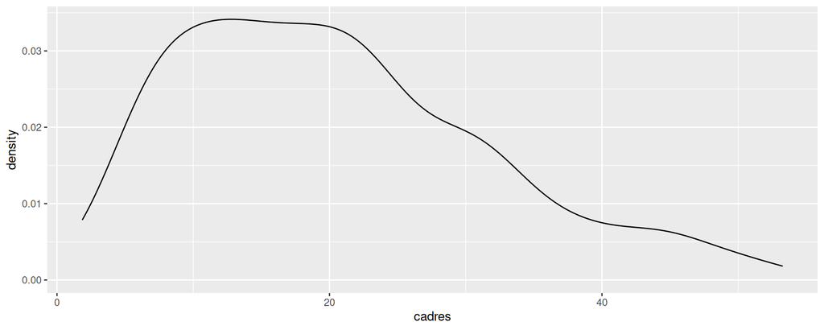

Both histogram and density plot can be displayed on the same graph  
`aes(y=after_stat(density))` to display the density on the y-axis

```r
ggplot(data=rp, aes(x=cadres)) +
  geom_histogram(aes(y=after_stat(density)), breaks=seq(0, 60, 10)) +
  geom_density()
```

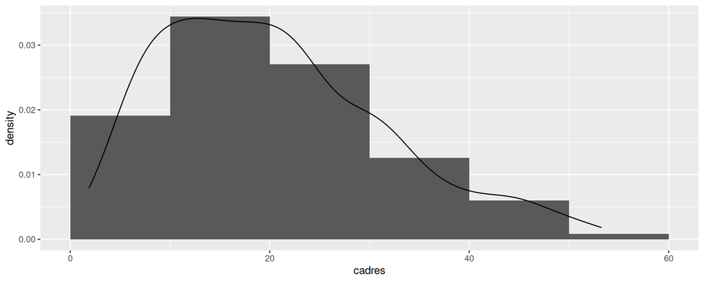

### Boxplot

**`geom_boxplot`**: another graph that can be used to visualize a quantitative variable.

- the box represents the first quartile (25% of the observations), the median (50%) and the third quartile (75%)
- the main rectangle therefore represent 50% of the observations (25% are below and 25% are above)
- the whiskers represent 1.5 times the inter-quartile.  
  *If one or several values are outside these whiskers they are displayed as points. Sometimes we consider theses values as outliers (additional tests must be made to be sure they can be removed from the analysis)*

```r
ggplot(data=rp) +
  geom_boxplot(aes(y=cadres))
```

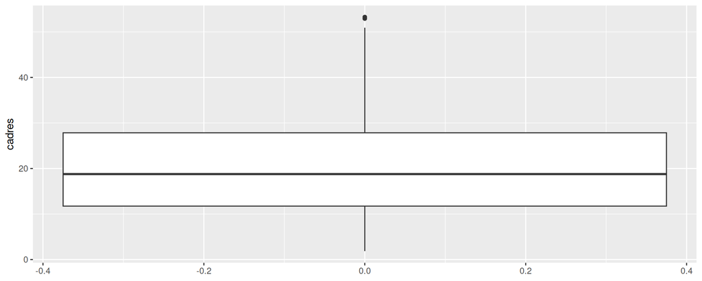

One boxplot for each modalities of a qualitative variable

```r
ggplot(data=rp) +
  geom_boxplot(aes(x=departement, y=cadres))
```

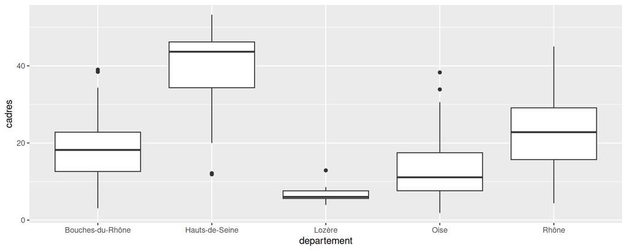

`varwidth=T` to have the width of the boxes proportional to the number of observations in each group

```r
ggplot(data=rp) +
  geom_boxplot(aes(x=departement, y=cadres), varwidth=T)
```

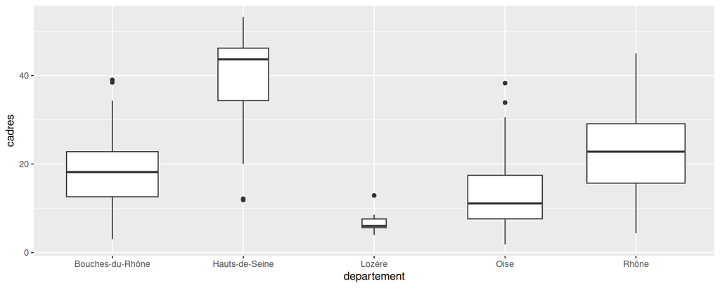

### Barplot

**`geom_bar`**: to display the effectives of each category of a qualitative variable

```r
ggplot(rp) +
  geom_bar(aes(x=departement))
```

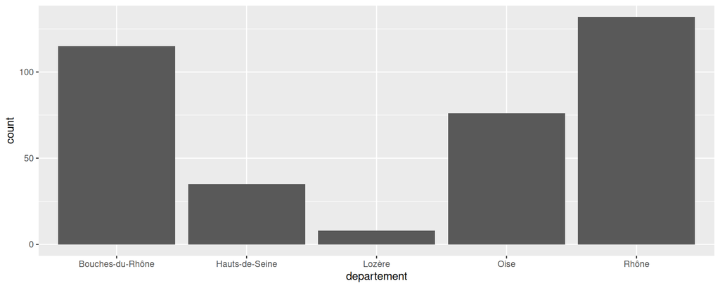

To display the proportions, we need to use `after_stat(prop)` with `group=1` to calculate the proportion for the whole dataset

```r
ggplot(rp) +
  geom_bar(aes(x=departement, y=after_stat(prop), group=1))
```

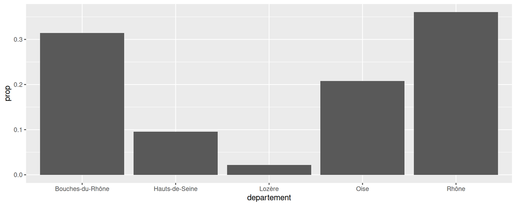

Another solution is to use `geom_col` to display calculated values

```r
rp |>
  group_by(departement) |>
  summarise(n=n()) |>
  mutate(percent=n/sum(n)*100) |>
  ggplot() +
  geom_col(aes(x=departement, y=percent))
```

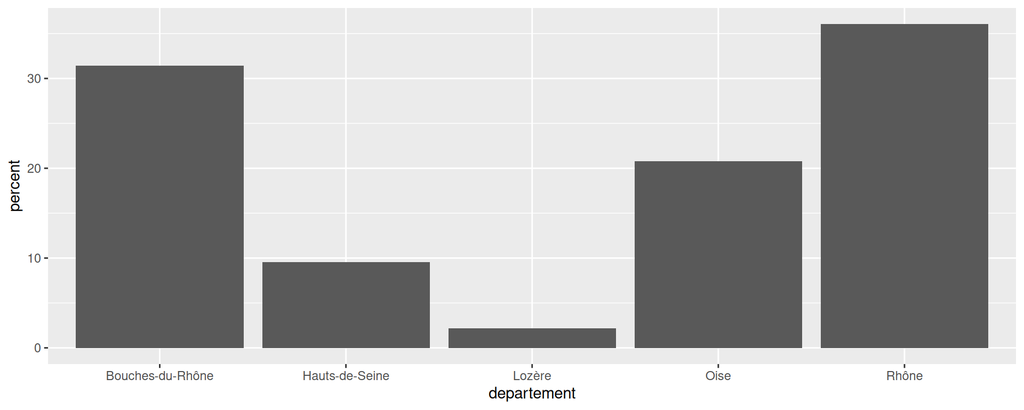

The slight difference between `geom_bar(after_stat)` and `geom_col with summarise` lies in when proportions are computed:

1. `geom_bar()`: automatically counts occurrences and applies after_stat(prop) at the plotting stage. Proportions are computed after binning, which may introduce slight rounding differences.
2. `summarise() + geom_col()`: counts (n = n()) and proportions (n / sum(n) * 100) are pre-computed before plotting. This guarantees a direct control over displayed percentages.

💡 Use `geom_bar()` for a quick approach without preprocessing and `geom_col()` for full control over calculations and additional statistics.

### Pie

**`geom_col` with polar coordinates**  
ggplot2 does not provide a `geom_pie` function, but it is possible to create a pie chart with `geom_bar` and polar coordinates

```r
rp |>
  group_by(departement) |>
  summarise(n=n()) |>
  mutate(percent=n/sum(n)*100) |>
  ggplot() +
  geom_col(aes(x="", y=percent, fill=departement)) +
  coord_polar("y", start=0)
```

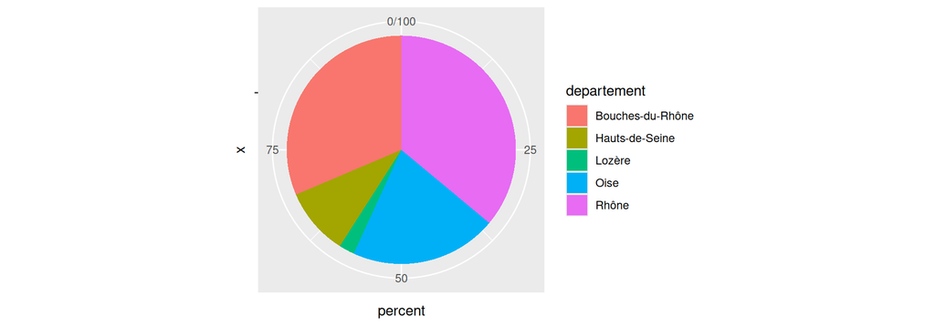

## Two variables

### Scatter plot

**`geom_point`**

```r
ggplot(data=rp2018) +
  geom_point(aes(x=cadres, y=dipl_sup))
```

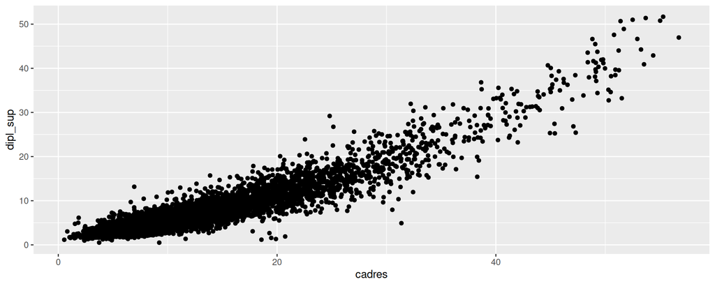

to add the regression line in the graph, use the geom_smooth function

```r
ggplot(data=rp2018, aes(x=cadres, y=dipl_sup)) +
  geom_point() +
  geom_smooth(method="lm")
```

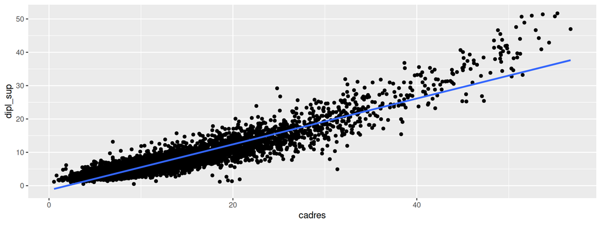

💡 Since the aes function should be used twice, we can add it in the ggplot call

### Line plot

**`geom_line`**

Load dataset ‘economics’ from the package ‘ggplot2’

```r
data(economics, package="ggplot2")
```

```r
ggplot(data=economics) +
  geom_line(aes(x=date, y=unemploy))
```

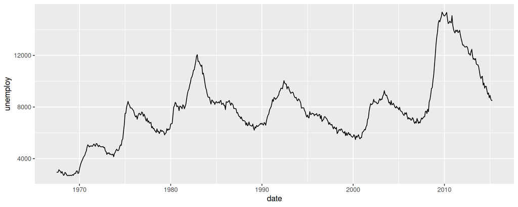

## Three and four variables

### Mapping

- associate an attribute of the graph (color, point size, marker) to the value of a categorical variable
- the mapping is done in the aes function

```r
ggplot(rp) +
  geom_point(aes(x = dipl_sup, y = cadres, color = departement))
```

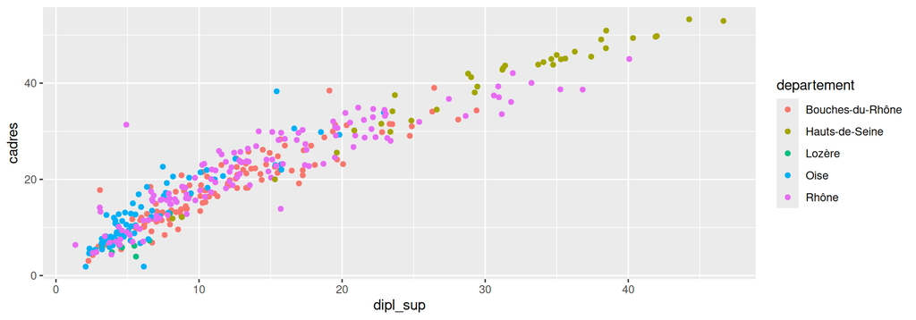

A fourth dimension through the size of the points which represents the total population of the commune

```r
ggplot(rp) +
  geom_point(aes(x=dipl_sup, y=cadres, color=departement, size=pop_tot))
```

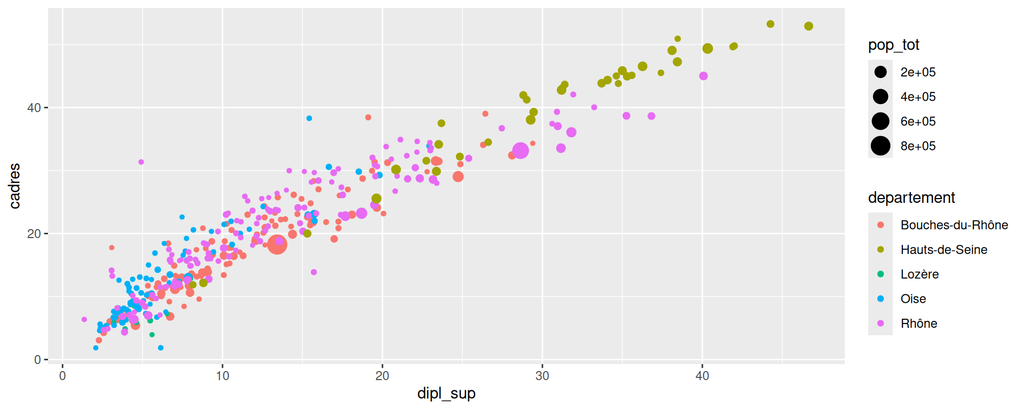

Possible to customize a mapping with `scale_`

```r
ggplot(rp) +
  geom_point(aes(x=dipl_sup, y=cadres, color=departement, size=pop_tot)) +
  scale_size("Population", breaks=c(0, 5000, 10000, 50000, 100000), range=c(0, 10))
```

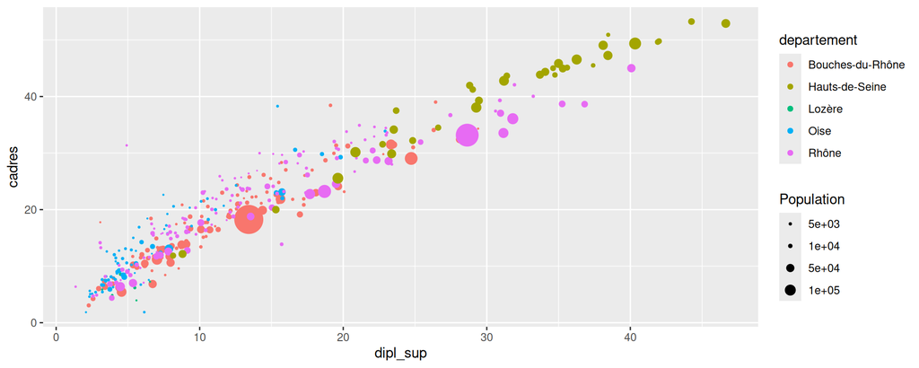

### Faceting

Repeat a graph several times according to one or several variables

```r
ggplot(rp) +
  geom_histogram(aes(x=cadres)) +
  facet_wrap(vars(departement))
```

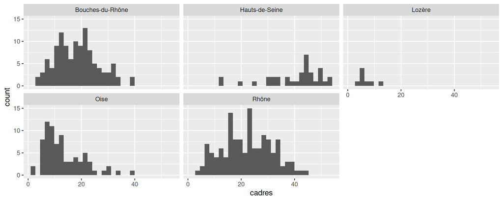

```r
ggplot(rp) +
  geom_point(aes(x=dipl_sup, y=cadres, color=pop_tot)) +
  facet_wrap(~departement)
```

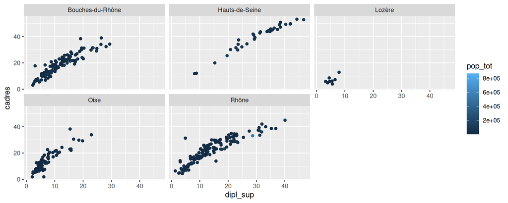

## Custumization

### Titles and labels

`labs` function to add titles and labels

```r
ggplot(rp) +
  geom_point(aes(x=dipl_sup, y=cadres, color=pop_tot)) +
  labs(title="Relation between Executives and Graduates", x="Graduates", y="Executives")
```

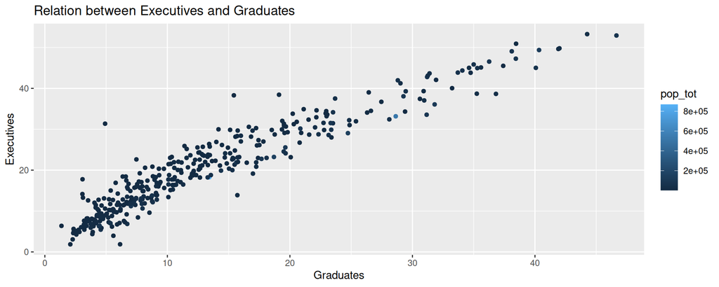

### Axes

`scale_x_continuous`, `scale_y_continuous` to customize the axes

```r
ggplot(rp) +
  geom_point(aes(x=dipl_sup, y=cadres, color=pop_tot)) +
  scale_x_continuous("Graduates", breaks=seq(0, 60, 10), limits=c(0, 60)) +
  scale_y_continuous("Executives", breaks=seq(0, 60, 10), limits=c(0, 60))
```

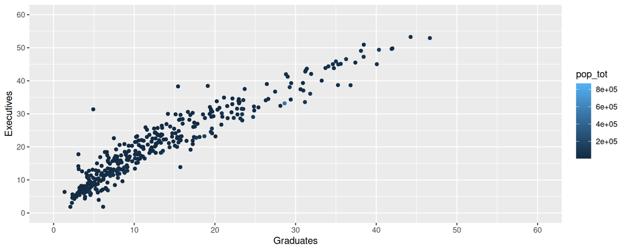

`scale_x_discrete`, `scale_y_discrete` for qualitative variables

```r
ggplot(rp) +
  geom_bar(aes(x=departement)) +
  scale_x_discrete("Departement") +
  scale_y_continuous("Number of observations")
```

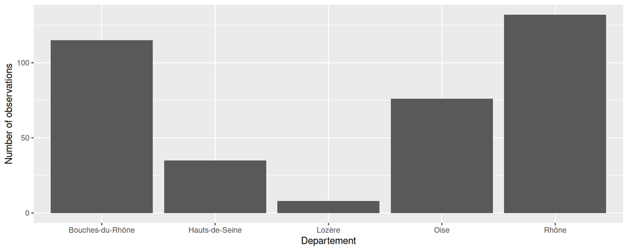